# hackseq: Trends in Bioinformatics

November 18, 2019

## `hackseq`

`hackseq` is a Vancouver-based hackathon focused on genomics. They want to bring individuals with diverse backgrounds together to collaborate on scientific questions and problems in genomics.

Their philosophy is **open-source**, **open-notebook**, **open science**.

[figure not shown]

Source: https://www.hackseq.com

## Project Goals

**Bioinformatics:** the development and use of computational methods in genetics and genomics

### **Graphic Visualization of trends in Bioinformatics**

1. Usage of bioinformatic tools and technqiues (ex. sequence alignment, genome assembly, metagenomics etc)
2. Relationship of tool development within analytical pipelines
3. Geographic hotspots for development of bioinformatic tools and techniques

**End product**: A visualization tool of trends in Bioinformatics, which can help prospective graduate students choose an institution or area of research.

Source: http://tiny.cc/hs19-readme

## Trends in Bioinformatics

#### **Workflow**

1. Divide the field of Bioinformatics into topics
   - Sequencing, Assembly, …
2. Determine search terms for each subjects
   - Sequencing: Sanger, next-generation sequencing, …
3. Analyze trends by webscraping/textmining
   - using `fulltext`, `pubchunks`

## Analogy

| Field | Topic | Search Terms |
| --- | --- | --- |
| Bioinformatics | Sequencing | Sanger, next-generation sequencing, … |
| Bioinformatics | Assembly | Short read assembly, long read assembly, … |
| Fruits | Apples | Ambrosia, Gala, McIntosh, Granny Smith, … |
| Fruits | Oranges | Navel, Mandarin, Tangerine, Clementine, … |

## Webscraping Results

Dataframe:

```
## # A tibble: 12 x 4
##    db        found searchTerm           topic
##    <chr>     <dbl> <chr>                <chr>
##  1 plos       9554 sanger sequencing    Sequencing
##  2 bmc       48995 sanger sequencing    Sequencing
##  3 crossref  37023 sanger sequencing    Sequencing
##  4 entrez    96509 sanger sequencing    Sequencing
##  5 arxiv     54228 sanger sequencing    Sequencing
##  6 scopus    89260 sanger sequencing    Sequencing
##  7 plos      34911 long read sequencing Sequencing
##  8 bmc      324406 long read sequencing Sequencing
##  9 crossref 434845 long read sequencing Sequencing
## 10 entrez   339648 long read sequencing Sequencing
## 11 arxiv    145774 long read sequencing Sequencing
## 12 scopus    39175 long read sequencing Sequencing
```

## Webscraping Results

Stacked Bar Graph:

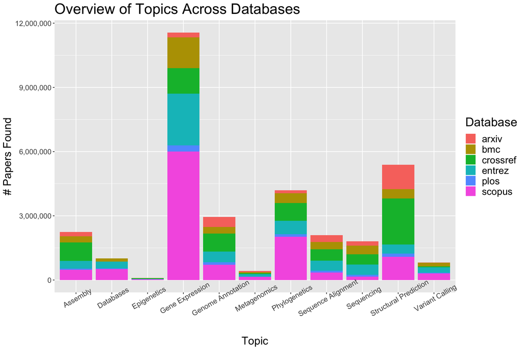

Source: https://dy-lin.github.io/hs19-trends/R/overview.html

## Our Dataset

Let’s look at the search terms of one specific topic, one specific jounral:

**Sequencing in the Public Library of Science (PLoS)**

```
## # A tibble: 10 x 9
##    doi    journal  publisher  author1  affiliation  title  abstract  topic  Year
##    <chr>  <chr>    <chr>      <chr>    <chr>        <chr>  <chr>     <chr> <dbl>
##  1 10.13… PLoS ONE Public Li… Zaragoz… Genetics & … Mitoc… Mutation… sang…  2010
##  2 10.13… PLoS ONE Public Li… Ji, Hez… National HI… HIV D… Backgrou… sang…  2010
##  3 10.13… PLOS ONE Public Li… Landria… Department … Inher… Spinocer… sang…  2017
##  4 10.13… PLOS ONE Public Li… Guinois… INSERM U966… Deep … Hepatiti… sang…  2017
##  5 10.13… PLOS ONE Public Li… Iyer, S… Department … Compa… Massivel… sang…  2015
##  6 10.13… PLOS ONE Public Li… Rebolle… Department … Compa… The refe… sang…  2015
##  7 10.13… PLOS ONE Public Li… Vivien,… Swiss Centr… Next-… Aquatic … sang…  2016
##  8 10.13… PLOS ONE Public Li… Pandey,… AIT Austria… MutAi… Traditio… sang…  2016
##  9 10.13… PLoS ONE Public Li… Lopez-R… Laboratorio… Compa… Backgrou… sang…  2012
## 10 10.13… PLoS ONE Public Li… Shokral… Biodiversit… Pyros… DNA barc… sang…  2011
```

To follow along with some live-coding, download these worksheets:

http://tiny.cc/rladies-ws1  
http://tiny.cc/rladies-ws2

## *Racing* Bar Graph

## What is a Racing Bar Graph?

[figure not shown]

Source: https://emilykuehler.github.io/bar-chart-race/

## What is a Racing Bar Graph?

[figure not shown]

Source: https://emilykuehler.github.io/bar-chart-race/

## Regular Bar Graph

First, let’s load our dataset and make a *regular* bar graph:

```r
base <- "https://raw.githubusercontent.com/dy-lin/hs19-trends/master/workshop/"
seq_spec <- "data/sequencing-specific-processed.csv"
url <- paste0(base, seq_spec)
seq_data <- read_csv(url)
```

A glimpse into the dataset (top 5):

| topic | Year | total | cum_total |
| --- | --- | --- | --- |
| illumina | 2013 | 171 | 404 |
| capillary | 2013 | 153 | 495 |
| sanger | 2013 | 152 | 406 |
| illumina | 2014 | 142 | 546 |
| 10x genomics | 2015 | 141 | 525 |

## Regular Bar Graph

```r
reg <- seq_data %>%
  drop_na() %>%
  ggplot(aes(x = topic, y = cum_total, fill = topic)) +
  geom_col() +
  facet_wrap(~ Year, ncol = 8) +
  coord_flip() +
  scale_fill_viridis_d() +
  theme(axis.text.y = element_blank(),
        axis.ticks.y = element_blank(),
        legend.position = "bottom") +
  geom_text(aes(y = cum_total,
                label = topic),
            hjust = "left",
            fontface = "bold",
            nudge_y = 50)
```

## Regular Bar Graph

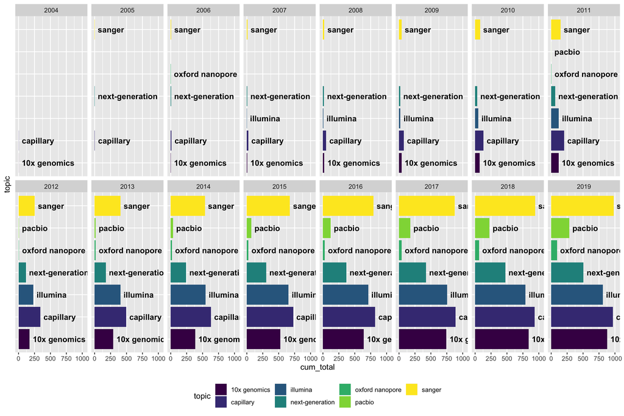

## *Racing* Bar Graph

In order to make a racing bar chart, where the bars overtake one another, we need to rank the topics for each year:

```r
ordered_df <- NULL

for (yr in 2003:2019) {
  order <- seq_data %>%
    filter(Year == yr) %>%
    arrange(cum_total) %>%
    mutate(ordering = row_number())

  ordered_df <- ordered_df %>% rbind(order)
}
```

## *Racing* Bar Graph

Here’s what the dataset looks like now:

| topic | Year | total | cum_total | ordering |
| --- | --- | --- | --- | --- |
| 10x genomics | 2004 | 1 | 1 | 1 |
| capillary | 2004 | 2 | 2 | 2 |
| next-generation | 2005 | 1 | 1 | 1 |
| sanger | 2005 | 1 | 1 | 2 |
| capillary | 2005 | 2 | 4 | 3 |
| oxford nanopore | 2006 | 1 | 1 | 1 |
| 10x genomics | 2006 | 1 | 2 | 2 |
| next-generation | 2006 | 4 | 5 | 3 |
| sanger | 2006 | 5 | 6 | 4 |

## *Racing* Bar Graph

Here is an overview of the code:

```r
# plot
p <- ordered_df %>%
  ggplot(aes(ordering, group = topic)) +
  geom_col(aes(y = cum_total, width = 0.9, fill = topic)) +
  geom_text(aes(y = cum_total, label = topic),
            hjust = "left", fontface = "bold", nudge_y = 50) +
  coord_cartesian(clip = "off", expand = FALSE) +
  scale_fill_viridis_d() +
  coord_flip() +
# animate
  transition_states(Year, transition_length = 8, state_length = 4, wrap = FALSE) +
  ease_aes("cubic-in-out") +
# aesthetics
  labs(subtitle = "Trends in sequencing methods", title = "Year {closest_state}",
       y = "cumulative total papers") +
  theme(plot.background = element_blank(), legend.position = "none",
        axis.ticks.y = element_blank(), axis.text.y = element_blank(),
        text = element_text(size=14), plot.title = element_text(size = 35)) +
  ylim(0,1300) +
  xlab("")
```

## *Racing* Bar Graph

Let’s start plotting:

```r
# plot
p <- ordered_df %>%
  ggplot(aes(ordering, group = topic)) +
  geom_col(aes(y = cum_total, width = 0.9, fill = topic)) +
  geom_text(aes(y = cum_total, label = topic),
            hjust = "left", fontface = "bold", nudge_y = 50) +
  coord_cartesian(clip = "off", expand = FALSE) +
  scale_fill_viridis_d() +
  coord_flip() +
# animate
  transition_states(Year, transition_length = 8, state_length = 4, wrap = FALSE) +
  ease_aes("cubic-in-out") +
# aesthetics
  labs(subtitle = "Trends in sequencing methods", title = "Year {closest_state}",
       y = "cumulative total papers") +
  theme(plot.background = element_blank(), legend.position = "none",
        axis.ticks.y = element_blank(), axis.text.y = element_blank(),
        text = element_text(size=14), plot.title = element_text(size = 35)) +
  ylim(0,1300) +
  xlab("")
```

## *Racing* Bar Graph

`coord_cartesian(clip = "off", expand = FALSE)`

#### Usage:

`coord_cartesian(xlim = NULL, ylim = NULL, expand = TRUE, default = FALSE, clip = "on")`

#### Description:

The Cartesian coordinate system is the most familiar, and common, type of coordinate system. Setting limits on the coordinate system will zoom the plot (like you’re looking at it with a magnifying glass), and will not change the underlying data like setting limits on a scale will.

#### Arguments

- `expand`: If `TRUE`, the default, adds a small expansion factor to the limits to ensure that data and axes don’t overlap. If `FALSE`, limits are taken exactly from the data or `xlim`/`ylim`.
- `clip`: Should drawing be clipped to the extent of the plot panel? A setting of “`on`” (the default) means yes, and a setting of “`off`” means no. In most cases, the default of “`on`” should not be changed, as setting clip = “`off`” can cause unexpected results. It allows drawing of data points anywhere on the plot, including in the plot margins.

## *Racing* Bar Graph

Next, to set up some animation parameters:

```r
# plot
p <- ordered_df %>%
  ggplot(aes(ordering, group = topic)) +
  geom_col(aes(y = cum_total, width = 0.9, fill = topic)) +
  geom_text(aes(y = cum_total, label = topic),
            hjust = "left", fontface = "bold", nudge_y = 50) +
  coord_cartesian(clip = "off", expand = FALSE) +
  scale_fill_viridis_d() +
  coord_flip() +
# animate
  transition_states(Year, transition_length = 8,
                    state_length = 4, wrap = FALSE) +
  ease_aes("cubic-in-out") +
# aesthetics
  labs(subtitle = "Trends in sequencing methods", y = "cumulative total papers",
       title = "Year {closest_state}") +
  theme(plot.background = element_blank(), legend.position = "none",
        axis.ticks.y = element_blank(), axis.text.y = element_blank(),
        text = element_text(size=14), plot.title = element_text(size = 35)) +
  ylim(0,1300) +
  xlab("")
```

## *Racing* Bar Graph

`transition_states(Year, transition_length = 8, state_length = 4, wrap = FALSE)`

#### Usage:

`transition_states(states, transition_length = 1, state_length = 1, wrap = TRUE)`

#### Description:

This transition splits your data into multiple states based on the levels in a given column, much like `ggplot2::facet_wrap()` splits up the data in multiple panels. It then tweens between the defined states and pauses at each state.

#### Arguments:

- `states`: The unquoted name of the column holding the state levels in the data.
- `transition_length`: The relative length of the transition. Will be recycled to match the number of states in the data
- `state_length`: The relative length of the pause at the states. Will be recycled to match the number of states in the data
- `wrap`: Should the animation wrap-around? If TRUE the last state will be transitioned into the first.

## *Racing* Bar Graph

`ease_aes("cubic-in-out")`

#### Usage:

`ease_aes(default = "linear", ...)`

#### Description:

Easing defines how a value change to another during tweening. Will it progress linearly, or maybe start slowly and then build up momentum. In `gganimate`, each aesthetic or computed variable can be tweened with individual easing functions using the `ease_aes()` function. All easing functions implemented in tweenr are available, see `tweenr::display_ease` for an overview. Setting an ease for x and/or y will also affect the other related positional aesthetics (e.g. `xmin`, `yend`, etc).

#### Functions

- `cubic`: Models a power-of-3 function
- `-in-out`: The first half of the transition it is applied as-is, while in the last half it is reversed

## *Racing* Bar Graph

Lastly, set up some aesthetics:

```r
# plot
p <- ordered_df %>%
  ggplot(aes(ordering, group = topic)) +
  geom_col(aes(y = cum_total, width = 0.9, fill = topic)) +
  geom_text(aes(y = cum_total, label = topic),
            hjust = "left", fontface = "bold", nudge_y = 50) +
  coord_cartesian(clip = "off", expand = FALSE) +
  scale_fill_viridis_d() +
  coord_flip() +
# animate
  transition_states(Year, transition_length = 8, state_length = 4, wrap = FALSE) +
  ease_aes("cubic-in-out") +
# aesthetics
  labs(subtitle = "Trends in sequencing methods",
       title = "Year {closest_state}", y = "cumulative total papers") +
  theme(plot.background = element_blank(), legend.position = "none",
        axis.ticks.y = element_blank(), axis.text.y = element_blank(),
        text = element_text(size=14), plot.title = element_text(size = 35)) +
  ylim(0,1300) +
  xlab("")
```

## *Racing* Bar Graph

Let’s animate!

The figure shown on the next slide was generated using these parameters:

```r
# render the animation
animate(p, nframes = 750, fps = 20, end_pause = 10)
```

However, due to the lengthy time it takes to generate, we should reduce these numbers:

```r
# rendering the animation
animate(p, nframes = 100, fps = 5, end_pause = 10)
```

## *Racing* Bar Graph

`animate(p, nframes = 100, fps = 5, end_pause = 10)`

#### Usage:

`animate(plot, ...)`

#### Description:

This function takes a `gganim` object and renders it into an animation. The nature of the animation is dependent on the renderer, but defaults to using `gifski` to render it to a gif. The length and framerate is decided on render time and can be any two combination of `nframes`, `fps`, and `duration`. Rendering is happening in discrete time units.

#### Arguments

- `plot`: A `gganim` object
- `nframes`: The number of frames to render (default `100`)
- `fps`: The framerate of the animation in frames/sec (default `10`)
- `duration`: The length of the animation in seconds (unset by default)
- `start_pause`,`end_pause`: Number of times to repeat the first and last frame in the animation (default is `0` for both)

## *Racing* Bar Graph

[figure not shown]

Source:https://dy-lin.github.io/hs19-trends/R/general_vis.html

## Sankey Diagrams

## What is a Sankey Diagram?

- **Sankey Diagram**: a type of flow diagram where the width of the arrows is proportional to the flow rate

[figure not shown]

  Source: https://cran.r-project.org/web/packages/googleVis/vignettes/googleVis_examples.html

## Sankey Diagrams

Here are the packages we need to load for a Sankey diagram:

```r
library(tidyverse)
library(ggrepel)
library(grid)
library(ggalluvial)
library(egg)
```

## Sankey Diagram

Let’s load in our pre-processed dataset:

```r
base <- "https://raw.githubusercontent.com/dy-lin/hs19-trends/master/workshop/"
SK <- "data/sankey-processed.csv"
url <- paste0(base, SK)
datSK <- read_csv(url)
```

| From | To | Weight | count |
| --- | --- | --- | --- |
| EMBL | Databases | 14 | 26 |
| Harvard U | Phylogenetics | 12 | 19 |
| U Washington | Variant Calling | 10 | 25 |
| Baylor College of Medicine | Variant Calling | 10 | 26 |
| UC San Diego | Genome Annotation | 8 | 17 |
| U Michigan | Phylogenetics | 8 | 16 |

## Sankey Diagram

Here’s an overview of plotting the Sankey diagram using `ggplot`:

```r
sankey <- ggplot(datSK, aes(y = Weight, axis1 = From, axis2 = To)) +
  geom_alluvium(aes(fill = From), width = 1 / 12) +
  geom_stratum(alpha = 0, width = 1 / 12, color = "black") +
  scale_x_discrete(limits = c("From", "To"), expand = c(0.3, 0.1)) +
  scale_fill_viridis_d() +
  theme_void() +
  theme(axis.title.y = element_blank(), axis.title.x = element_blank(),
    axis.ticks.x = element_blank(), axis.ticks.y = element_blank(),
    axis.text.x = element_blank(),axis.text.y = element_blank(),
    legend.position = "none", plot.title = element_text(hjust = 0.5)) +
  ggrepel::geom_label_repel(
    aes(label = From), stat = "stratum", size = 3, direction = "x", hjust = 10) +
  ggrepel::geom_label_repel(
    aes(label = To), stat = "stratum", size = 3, direction = "y", nudge_x = 0.5) +
  geom_label(aes(label = Weight), stat = "stratum", alpha = 0.8) +
  ggtitle("Top 10 Institutions Publications By Topic")

sankey <- set_panel_size(sankey, width  = unit(18, "cm"), height = unit(10, "cm"))
grid.newpage()
grid.draw(sankey)
```

## Sankey Diagram

Let’s take a closer look at the `geom` functions used:

```r
sankey <- ggplot(datSK, aes(y = Weight, axis1 = From, axis2 = To)) +
  geom_alluvium(aes(fill = From), width = 1 / 12) +
  geom_stratum(alpha = 0, width = 1 / 12, color = "black") +
  scale_x_discrete(limits = c("From", "To"), expand = c(0.3, 0.1)) +
  scale_fill_viridis_d() +
  theme_void() +
  theme(axis.title.y = element_blank(), axis.title.x = element_blank(),
    axis.ticks.x = element_blank(), axis.ticks.y = element_blank(),
    axis.text.x = element_blank(),axis.text.y = element_blank(),
    legend.position = "none", plot.title = element_text(hjust = 0.5)) +
  ggrepel::geom_label_repel(
    aes(label = From), stat = "stratum", size = 3, direction = "x", hjust = 10) +
  ggrepel::geom_label_repel(
    aes(label = To), stat = "stratum", size = 3, direction = "y", nudge_x = 0.5) +
  geom_label(aes(label = Weight), stat = "stratum", alpha = 0.8) +
  ggtitle("Top 10 Institutions Publications By Topic")

sankey <- set_panel_size(sankey, width  = unit(18, "cm"), height = unit(10, "cm"))
grid.newpage()
grid.draw(sankey)
```

## Sankey Diagram

`geom_alluvium(aes(fill = From), width = 1 / 12)`

#### Usage:

`geom_alluvium(mapping = NULL, data = NULL, stat = "alluvium", position = "identity", width = 1/3, knot.pos = 1/6, na.rm = FALSE, show.legend = NA, inherit.aes = TRUE, ...)`

#### Description:

`geom_alluvium` receives a dataset of the horizontal (`x`) and vertical (`y`, `ymin`, `ymax`) positions of the **lodes** of an alluvial diagram, the intersections of the alluvia with the strata. It plots both the lodes themselves, using `geom_lode()`, and the flows between them, using `geom_flow()`.

#### Arguments:

- `mapping`: Set of aesthetic mappings created by `aes()`
- `width`: Numeric; the width of each stratum, as a proportion of the distance between axes. Defaults to 1/3.

## Sankey Diagram

`geom_stratum(alpha = 0, width = 1 / 12, color = "black")`

#### Usage:

`geom_stratum(mapping = NULL, data = NULL, stat = "stratum", position = "identity", show.legend = NA, inherit.aes = TRUE, width = 1/3, na.rm = FALSE, ...)`

#### Description:

`geom_stratum` receives a dataset of the horizontal (`x`) and vertical (`y`, `ymin`, `ymax`) positions of the strata of an alluvial diagram. It plots rectangles for these strata of a provided `width`.

#### Arguments:

- `width`: Numeric; the width of each stratum, as a proportion of the distance between axes. Defaults to 1/3.

## Sankey Diagram

[figure not shown]

Source: https://dy-lin.github.io/hs19-trends/R/visualization_sankey.html

## Mapping

## Mapping

We want to look at several trends

- Most Common topic per country
- Number of papers per country

If you still haven’t downloaded the live-coding worksheet for this section:

http://tiny.cc/rladies-ws2

## Mapping

[figure not shown]

Source: https://dy-lin.github.io/hs19-trends/R/visualization_map.html

## Mapping

Here are all the packages we need to format the data and do the plotting

```r
library(ggplot2)
library(dplyr)
library(plotly)
library(here)
library(ggmap)
library(viridis)
library(rgeos)
library(maptools)
library(maps)
library(sf)
library(readr)
library(tidyverse)
library(knitr)
library(broom)
```

## Mapping

Packages needed for plotting

`ggplot2`: package for data visualizations

`plotly`: makes interactive visualizations

`viridis`: good colour palatte for dealing with colourblindness and greyscale issues

## Mapping

There is a lot of code in the worksheet that describes how we got the data into the format we needed

- We will do one global plot and one of Europe

## Mapping

Here is an example of what the data looks like:

|  | long | lat | group | order | region | subregion | Count | topicMax |
| --- | --- | --- | --- | --- | --- | --- | --- | --- |
| 14572 | -61.10518 | 45.94472 | 252 | 14823 | Canada | Cape Breton Island | 616 | transcript quantification |
| 14573 | -61.07134 | 45.93711 | 252 | 14824 | Canada | Cape Breton Island | 616 | transcript quantification |
| 14574 | -60.93657 | 45.98555 | 252 | 14825 | Canada | Cape Breton Island | 616 | transcript quantification |
| 14575 | -60.86524 | 45.98350 | 252 | 14826 | Canada | Cape Breton Island | 616 | transcript quantification |
| 14576 | -60.86840 | 45.94863 | 252 | 14827 | Canada | Cape Breton Island | 616 | transcript quantification |
| 14577 | -60.98428 | 45.91069 | 252 | 14828 | Canada | Cape Breton Island | 616 | transcript quantification |
| 14578 | -61.03755 | 45.88222 | 252 | 14829 | Canada | Cape Breton Island | 616 | transcript quantification |
| 14579 | -60.97060 | 45.85581 | 252 | 14830 | Canada | Cape Breton Island | 616 | transcript quantification |
| 14580 | -60.97153 | 45.83799 | 252 | 14831 | Canada | Cape Breton Island | 616 | transcript quantification |

## Mapping

```r
pl <- ggplot() +
  geom_polygon(data = world_data2, aes(x = long, y = lat,
  group = group,fill = log(Count),text=Count),colour="lightgrey") +
  coord_fixed(1.3)+
  scale_fill_viridis()+
  theme_void()

world_plotly=ggplotly(pl,tooltip = "text")
```

## Mapping

`geom_polygon(data = world_data2, aes(x = long, y = lat,group = group,fill = log(Count),text=Count))`

#### Usage

`geom_polygon:mapping = NULL, data = NULL, stat = "identity",position = "identity", rule = "evenodd", ..., na.rm = FALSE,show.legend = NA, inherit.aes = TRUE)`

#### Description

Polygons are very similar to paths (as drawn by geom_path()) except that the start and end points are connected and the inside is coloured by fill. The group aesthetic determines which cases are connected together into a polygon.

#### Arguments

`group`:By default, the group is set to the interaction of all discrete variables in the plot. This often partitions the data correctly, but when it does not, or when no discrete variable is used in the plot, you will need to explicitly define the grouping structure, by mapping group to a variable that has a different value for each group.

## Mapping

```r
pl <- ggplot() +
  geom_polygon(data = world_data2, aes(x = long, y = lat,
  group = group,fill = log(Count),text=Count)) +
  coord_fixed(1.3)+
  scale_fill_viridis()+
  theme_void()

world_plotly=ggplotly(pl,tooltip = "text")
```

## Mapping

[figure not shown]

Source: https://dy-lin.github.io/hs19-trends/R/visualization_map.html

## Mapping

If we want to look at certain countries we can do that too

- depending on how much data is in one region this may be a good idea
- will have to figure out the coordinates you want
- plot will be set up similarily to the global one but we will add in new elements

## Mapping

|  | X | region | Count | long | lat | group | order | subregion |
| --- | --- | --- | --- | --- | --- | --- | --- | --- |
| 67 | 67 | Albania | 0 | 19.96484 | 39.87227 | 6 | 836 | NA |
| 68 | 68 | Albania | 0 | 19.85186 | 40.04356 | 6 | 837 | NA |
| 69 | 69 | Albania | 0 | 19.48457 | 40.20996 | 6 | 838 | NA |
| 70 | 70 | Albania | 0 | 19.39814 | 40.28486 | 6 | 839 | NA |
| 71 | 71 | Albania | 0 | 19.36016 | 40.34771 | 6 | 840 | NA |
| 72 | 72 | Albania | 0 | 19.32227 | 40.40708 | 6 | 841 | NA |

## Mapping

```r
 pl <- ggplot() +
  geom_polygon(data = europe_data, aes(x = long, y = lat,
  group = group, fill = log(Count),
  text=paste(region,Count, sep=";"))) +
  geom_point(data=points_europe,aes(x=X,y=Y,
  text=str_wrap(affiliation,50)),
  alpha=0.5,size=0.5,colour="grey")+
  coord_fixed(1.3)+
  scale_fill_viridis()+
  theme_void()
```

## Mapping

```r
 pl <- ggplot() +
  geom_polygon(data = europe_data, aes(x = long, y = lat,
  group = group, fill = log(Count),
  text=paste(region,Count, sep=";"))) +
  geom_point(data=points_europe,aes(x=X,y=Y,
  text=str_wrap(affiliation,50)),
  alpha=0.5,size=0.5,colour="grey")+
  coord_fixed(1.3)+
  scale_fill_viridis()+
  theme_void()
```

## Mapping

[figure not shown]

Source: https://dy-lin.github.io/hs19-trends/R/visualization_map.html

## Bigrams

## Bigrams

**Bigrams** are two consecutive words within a given text input

- ex. We love coding in R
- (We Love), (Love coding), (coding in), (in R)

## Bigrams

```r
library(tidyverse)
library(tidytext)
library(tm)
library(widyr)
library(igraph)
library(ggplot2)
library(ggraph)
library(readr)
library(tidygraph)
```

## Bigrams

`ggraph`: visualizations for network structures

`ggplot2`: package for data visualizations

## Bigrams

**visualize_bigrams**: extracts bigrams from a text field, calculates frequency of bigrams, and creates a bigram plot to visualize relationships between words

- `df_name`: name of dataframe that contains the text field of interest
- `textfield`: name of text field (ie. column name)

```r
visualize_bigrams <- function(df_name, textfield, topic_title)
```

## Bigrams

In the worksheet, you will see a lot of code that just talks about the formatting of the data. If you are interested in that look into it, but we’re just covering the plotting

## Bigrams

```r
pl <- graph_hold %>%
      ggraph(layout = "fr") +
      geom_edge_link(aes(edge_alpha = Edge_Frequency),
      show.legend = TRUE) +
      geom_node_point(aes(color = Term_Frequency,
      size = Term_Frequency), alpha = 0.7) +
      scale_fill_viridis_c() +
      geom_node_text(aes(label = name), repel = TRUE) +
      scale_color_viridis_c(direction = -1) +
      theme_void() +
      guides(size=FALSE) +
      labs(title = quo_name(topic_title)) +
      theme(plot.title = element_text(size = 26, face = "bold"))
```

## Bigrams

`geom_edge_link(aes(edge_alpha = Edge_Frequency),show.legend = TRUE)`

#### Usage

`geom_edge_link(mapping = NULL, data = get_edges("short"),position = "identity", arrow = NULL, n = 100, lineend = "butt",linejoin = "round", linemitre = 1, label_colour = "black",label_alpha = 1, label_parse =FALSE, check_overlap = FALSE,angle_calc = "rot", force_flip = TRUE, label_dodge = NULL,label_push = NULL, show.legend = NA, ...)`

#### Description

This geom draws edges in the simplest way - as straight lines between the start and end nodes. Not much more to say about that…

## Bigrams

`ggraph(layout = "fr")`

#### Usage

`ggraph(graph, layout = "auto", ...)`

#### Description

This function is the equivalent of `ggplot2::ggplot()` in `ggplot2`. It takes care of setting up the plot object along with creating the layout for the plot based on the graph and the specification passed in. Alternatively a layout can be prepared in advance using create_layout and passed as the data argument.

#### Arguments

`layout`:The type of layout to create. Either a valid string, a function, a matrix, or a data.frame

- fr is within the igraph layout options for constucting node diagrams

## Bigrams

`geom_node_point(aes(color = Term_Frequency, size = Term_Frequency), alpha = 0.7)`

#### Usage

`geom_node_point: geom_node_point(mapping = NULL, data = NULL, position = "identity",show.legend = NA, ...)`

#### Description

This geom is equivalent in functionality to `ggplot2::geom_point()` and allows for simple plotting of nodes in different shapes, colours and sizes.

#### Arguments

We don’t use any arguments in this case, just change some of the aes

## Bigrams

```
##
##
## |Search Term           |
## |:---------------------|
## |Assembly              |
## |Databases             |
## |Epigenetics           |
## |Gene Expression       |
## |Genome Annotation     |
## |Phylogenetics         |
## |Sequence Alignment    |
## |Sequencing            |
## |Structural Prediction |
## |Variant Calling       |
```

## Bigrams

```r
df_assembly <- df %>%
  filter(topic == "Assembly")
visualize_bigrams(df_assembly, abstract, "")
```

## Bigrams

[figure not shown]

Source: https://dy-lin.github.io/hs19-trends/R/bigram_relationships.html

## GitHub

For more information regarding the Hackseq project: https://github.com/dy-lin/hs19-trends

## Acknowledgements

- Jasmine Lai
- Raissa Philibert
- Lucia Darrow
- Shannon Lo
- Morgana Xu
- Elliot YKF
- Swapna Menon

**Thank you RLadies and Dialpad for hosting us!**